# Analyzing Bike Rides

FT

Sunday, January 25, 2015

I pulled last year’s data from the “CallaBike”-SOAP API.

```r
length(grep("StartTime", raw$V1,))
```

```
## [1] 403
```

So it looks like did 403 trips using a Call a Bike in 2014. Next we need some data cleaning.

```
## [1] "MAX drive time:"
```

```
## Time difference of 9571 secs
```

remove an unreasonable high drive time. Next we will get an initial glimpse at the data.

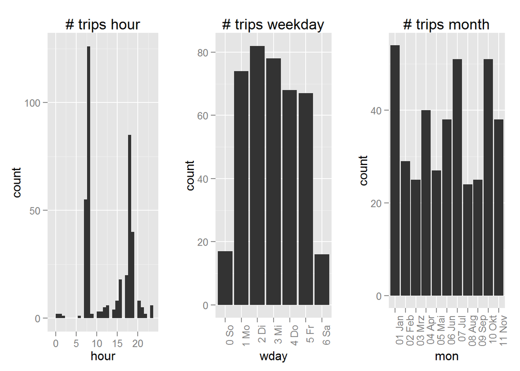

We see a clear pattern of high usage during the week and at commuting hours.

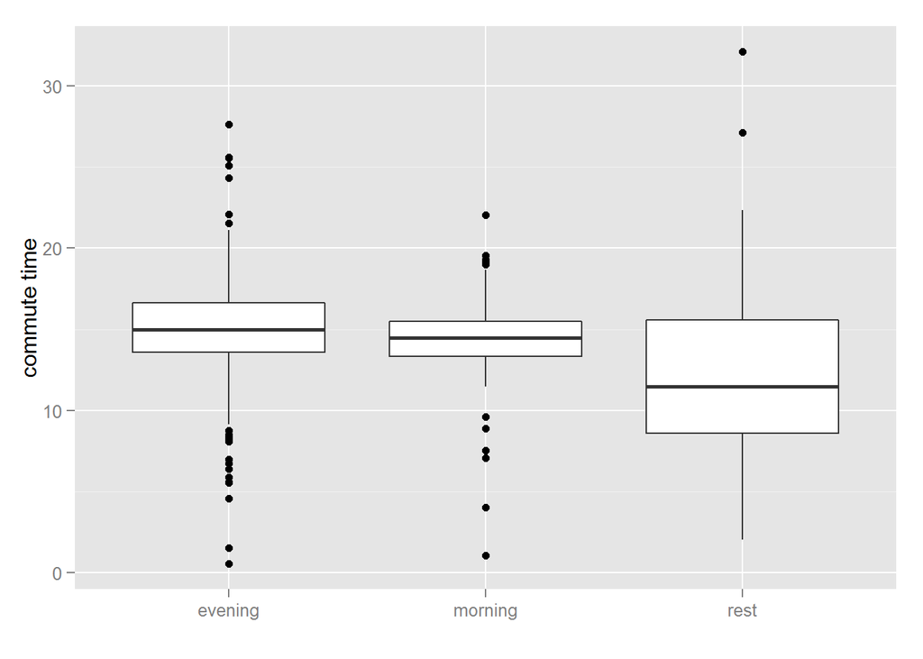

Commute times are basically the same for the morning/evening trips.

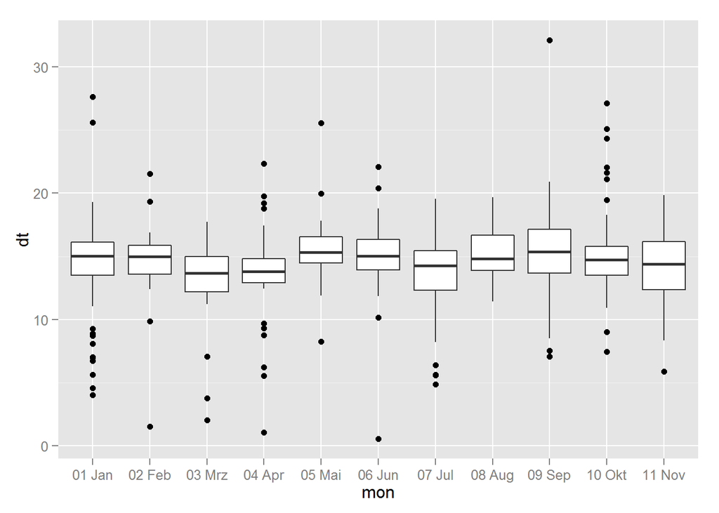

Commute times did not change over the year. (some ups and downs -but it’s basically stable.)

According to google maps the distance is 4.9km. Which makes a total of

```
## [1] 1970
```

KM in 2014. at an average speed of:

```
## [1] 20.45
```

As this data indicates starting and ending of commutes, we can calculate the time spend at work.

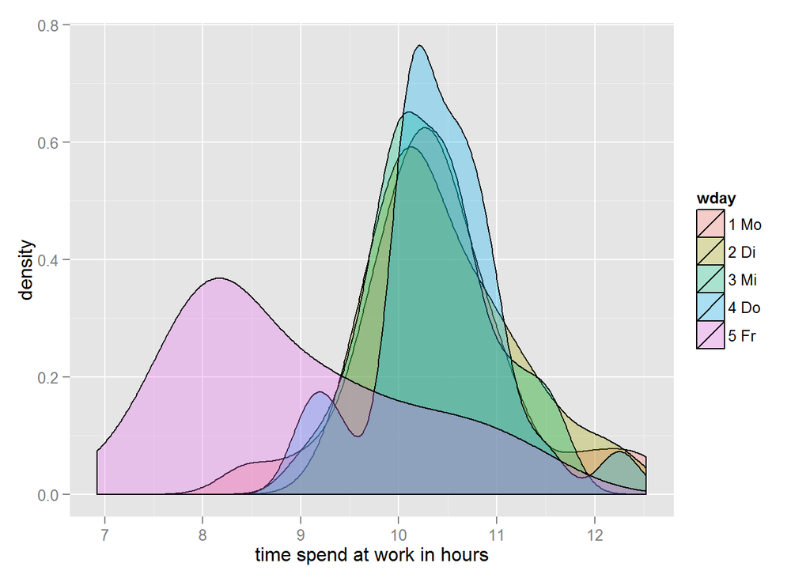

```
## [1] 10.1
```

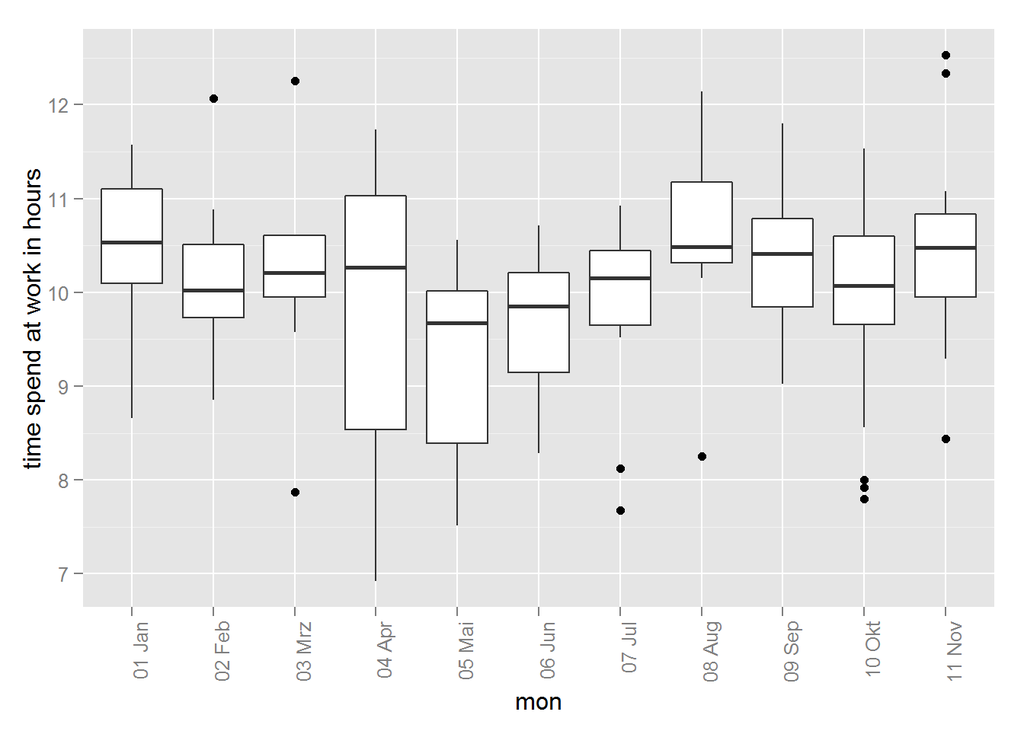

And finally some regression model ;)

```r
stargazer(lm1, lm,  type = "html", title="Explain time spend at work.")
```

**Explain time spend at work.**

|  | *Dependent variable:* |  |
| --- | --- | --- |
|  | wt |  |
|  | (1) | (2) |
| wday2 Di | 0.154 | 0.115 |
|  | (0.188) | (0.186) |
| wday3 Mi | 0.022 | 0.004 |
|  | (0.190) | (0.186) |
| wday4 Do | 0.108 | 0.144 |
|  | (0.204) | (0.200) |
| wday5 Fr | -1.499*** | -1.536*** |
|  | (0.197) | (0.193) |
| mon02 Feb | -0.726** | -0.775*** |
|  | (0.284) | (0.279) |
| mon03 Mrz | -0.613** | -0.680** |
|  | (0.302) | (0.296) |
| mon04 Apr | -0.842*** | -0.930*** |
|  | (0.261) | (0.258) |
| mon05 Mai | -1.369*** | -1.303*** |
|  | (0.290) | (0.286) |
| mon06 Jun | -1.260*** | -1.262*** |
|  | (0.254) | (0.250) |
| mon07 Jul | -0.858*** | -0.947*** |
|  | (0.234) | (0.234) |
| mon08 Aug | -0.395 | -0.406 |
|  | (0.286) | (0.280) |
| mon09 Sep | -0.600** | -0.585** |
|  | (0.296) | (0.290) |
| mon10 Okt | -0.922*** | -0.894*** |
|  | (0.237) | (0.233) |
| mon11 Nov | -0.559** | -0.656*** |
|  | (0.251) | (0.250) |
| dt.x |  | -0.037 |
|  |  | (0.025) |
| dt.y |  | -0.041** |
|  |  | (0.016) |
| Constant | 11.070*** | 12.250*** |
|  | (0.213) | (0.487) |
| Observations | 161 | 161 |
| R<sup>2</sup> | 0.491 | 0.520 |
| Adjusted R<sup>2</sup> | 0.442 | 0.466 |
| Residual Std. Error | 0.759 (df = 146) | 0.743 (df = 144) |
| F Statistic | 10.070*** (df = 14; 146) | 9.743*** (df = 16; 144) |
| *Note:* | p<0.1; p<0.05; p<0.01 |  |

why is time spend at work negatively correlated with drive time?

```r
lm3 <- lm(dt.y~wt, data=working)
lm4 <- lm(dt.y~wt+wday, data=working)
lm5 <- lm(dt.y~wt+wday +mon, data=working)

stargazer(lm3,lm4,lm5,  type = "html", title="Explain time spend at work.")
```

**Explain time spend at work.**

|  | *Dependent variable:* |  |  |
| --- | --- | --- | --- |
|  | dt.y |  |  |
|  | (1) | (2) | (3) |
| wt | -0.558* | -0.759** | -1.061** |
|  | (0.308) | (0.381) | (0.420) |
| wday2 Di |  | -1.534 | -1.367 |
|  |  | (0.968) | (0.958) |
| wday3 Mi |  | -0.447 | -0.324 |
|  |  | (0.967) | (0.963) |
| wday4 Do |  | 0.276 | 0.592 |
|  |  | (1.044) | (1.034) |
| wday5 Fr |  | -1.438 | -2.103* |
|  |  | (1.127) | (1.182) |
| mon02 Feb |  |  | -2.597* |
|  |  |  | (1.470) |
| mon03 Mrz |  |  | -2.163 |
|  |  |  | (1.553) |
| mon04 Apr |  |  | -3.239** |
|  |  |  | (1.371) |
| mon05 Mai |  |  | -1.090 |
|  |  |  | (1.582) |
| mon06 Jun |  |  | -2.306* |
|  |  |  | (1.391) |
| mon07 Jul |  |  | -3.666*** |
|  |  |  | (1.242) |
| mon08 Aug |  |  | -0.901 |
|  |  |  | (1.460) |
| mon09 Sep |  |  | -0.042 |
|  |  |  | (1.521) |
| mon10 Okt |  |  | -1.016 |
|  |  |  | (1.265) |
| mon11 Nov |  |  | -3.420*** |
|  |  |  | (1.297) |
| Constant | 20.700*** | 23.410*** | 28.390*** |
|  | (3.130) | (4.019) | (4.771) |
| Observations | 161 | 161 | 161 |
| R<sup>2</sup> | 0.020 | 0.051 | 0.157 |
| Adjusted R<sup>2</sup> | 0.014 | 0.020 | 0.070 |
| Residual Std. Error | 3.966 (df = 159) | 3.953 (df = 155) | 3.852 (df = 145) |
| F Statistic | 3.271* (df = 1; 159) | 1.660 (df = 5; 155) | 1.800** (df = 15; 145) |
| *Note:* | p<0.1; p<0.05; p<0.01 |  |  |